# Lancaster County Development

Jonathan Manurung

September, 2023

# Why Urban Sprawl Matters?

Urban sprawl has become one of the challenges for fast-growing metro areas in the United States. This phenomenon happens due to the uncontrolled expansion of urban areas. The expansion spread to the surrounding suburb to accommodate the living space for the city residents. This practice promotes car-dependent communities, increase in higher infrastructure costs, generates air and water pollution, and especially the loss of natural and agriculture land which tend to be unsustainable.

Philadelphia is one of the cities that has experienced the rapid growth, and the urban sprawl phenomenon has happened to the surrounding suburban areas including Lancaster County, which is one of the largest agricultural producers in Pennsylvania. Some sources indicated urban sprawl trend in Lancaster County, and predict it will continue to happen if no appropriate action is taken.

# Initiatives to Control the Urban Sprawl in Lancaster County

This Lancaster County’s UGA wants to limit the development outside the UGA and protect the farmland. However, the reality on the ground shows that development has continued outside the UGA and the agriculture land is being paved over for suburban residential area, which suggest that the UGA is not enough to contain the sprawl. A reasonable policy regarding the UGA expansion might be a solution to this matter - but to which direction? A simple economic model can be used to identify which area best suited for expanding the UGA in Lancaster County.

## Lancaster County bid-rent model

Bid-rent model is a model that used to understand the spatial pattern of building density and distance from the urban core in a city. This model generally suggest that distance from the city center increases, building density decreases. This model can be used to identify suitable towns for Lancaster County’s UGA expansion. A buffer inside and outside of the UGA boundary (see Figure 2) is used to determine which surrounding towns have the greatest infill potential, by looking at the difference of their building density on either side of the boundary.

In order to do the analysis, buffer for 1/8th mile inside and outside UGA’s boundary are generated, then associated this buffer to every surrounding towns which have the intersection to the buffer(see Figure 3).

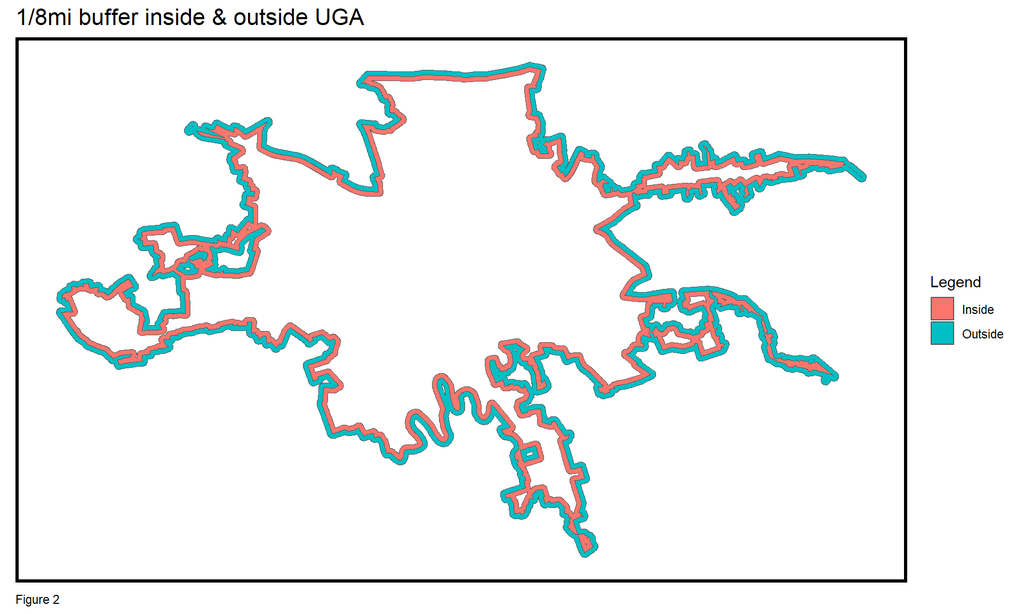

```r
outsideBuffer <-
  st_buffer(uga_union, 660) %>%
  st_difference(uga_union) %>%
  mutate(Legend = "Outside")


insideBuffer <-
  st_buffer(uga_union, dist = -660) %>%
  st_difference(uga_union, .) %>%
  mutate(Legend = "Inside")

bothBuffers <- rbind(insideBuffer, outsideBuffer)

buffer <-
  ggplot() +
  geom_sf(data = bothBuffers, aes(fill = Legend)) +
  scale_fill_manual(values = c("#F8766D", "#00BFC4")) +
  labs(title = "1/8mi buffer inside & outside UGA", caption = "Figure 2") +
  mapTheme()

buffersAndTowns <-
  st_intersection(st_make_valid(studyAreaTowns),
                  bothBuffers) %>%
  filter(MUNI != "MOUNTVILLE BOROUGH"& MUNI != "MILLERSVILLE BOROUGH")

buffertowns <-
  ggplot() +
  geom_sf(data = buffersAndTowns, aes(fill=MUNI, alpha =Legend))+
  scale_alpha_manual(values = c("Inside" = 1, "Outside" = 0.2))+
  labs(title = "Inside/Outside the UGA by town", subtitle = "Comparable shades of the same color represent inside/outside the UGA by town", caption = "Figure 3")+
  guides(fill = guide_legend(ncol = 2))+
  theme(plot.title = element_text(size = 12), plot.subtitle = element_text(size = 10))+
  mapTheme()

print(buffer)
```

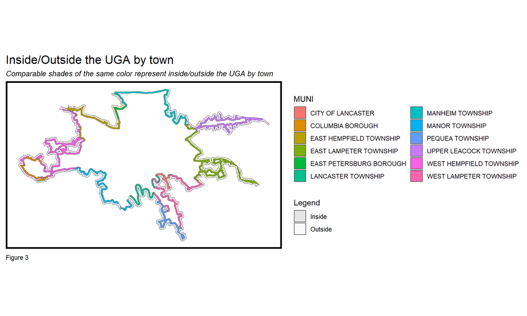

```r
print(buffertowns)
```

The bid-rent model use building density data to see the significant difference between building density inside and outside the boundary. In this case, building density is calculated by percentage of building count per area for each town portion, in the buffer of inside and outside of UGA’s boundary (see Table 1). For a sense of spatial perspective, a building density inside West Hempfield Townships’s UGA is visualized as an example (see Figure 4)

```r
buildingCentroids <-
  st_centroid(buildings) %>%
  mutate(counter = 1) %>%
  dplyr::select(counter)

buffersAndTowns_Buildings <-
  aggregate(buildingCentroids, buffersAndTowns, sum) %>%
  cbind(buffersAndTowns) %>%
  mutate(counter = replace_na(counter, 0),
         Area = as.numeric(st_area(.)))

buffersAndTowns_Buildings_Summarize <-
  buffersAndTowns_Buildings %>%
  group_by(MUNI, Legend) %>%
    summarize(Building_Count = sum(counter),
              Area = sum(Area)) %>%
    mutate(Building_Density = Building_Count / Area)

buildingDifferenceTable <-
  st_drop_geometry(buffersAndTowns_Buildings_Summarize) %>%
    dplyr::select(MUNI, Legend, Building_Density) %>%
    spread(Legend, Building_Density) %>%
      mutate(Building_Difference = Inside - Outside) %>%
      arrange(desc(Building_Difference)) %>%
   filter(!is.na(Building_Difference))


buildingDifferenceTable %>%
  kable() %>%
  kable_styling() %>%
  footnote(general_title = "\n",
             general = "Table 1")
```

| MUNI | Inside | Outside | Building_Difference |
| --- | --- | --- | --- |
| EAST PETERSBURG BOROUGH | 0.0000304 | 0.0000000 | 0.0000304 |
| WEST LAMPETER TOWNSHIP | 0.0000190 | 0.0000021 | 0.0000169 |
| WEST HEMPFIELD TOWNSHIP | 0.0000198 | 0.0000033 | 0.0000165 |
| UPPER LEACOCK TOWNSHIP | 0.0000177 | 0.0000033 | 0.0000144 |
| EAST LAMPETER TOWNSHIP | 0.0000170 | 0.0000050 | 0.0000120 |
| COLUMBIA BOROUGH | 0.0000100 | 0.0000000 | 0.0000100 |
| MANHEIM TOWNSHIP | 0.0000094 | 0.0000020 | 0.0000074 |
| PEQUEA TOWNSHIP | 0.0000113 | 0.0000048 | 0.0000065 |
| LANCASTER TOWNSHIP | 0.0000065 | 0.0000000 | 0.0000065 |
| MANOR TOWNSHIP | 0.0000094 | 0.0000038 | 0.0000057 |
| EAST HEMPFIELD TOWNSHIP | 0.0000061 | 0.0000037 | 0.0000024 |
| CITY OF LANCASTER | 0.0000014 | 0.0000000 | 0.0000014 |

Table 1

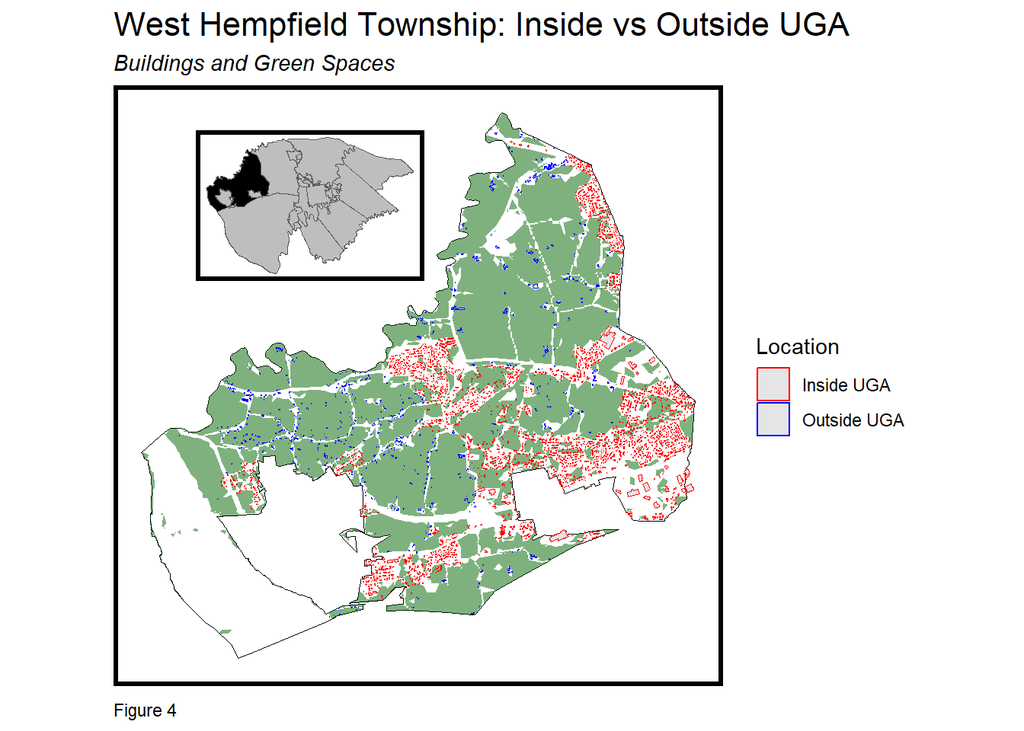

```r
westHempfield <-
  filter(studyAreaTowns, MUNI == "WEST HEMPFIELD TOWNSHIP")

uga_WH <-
  st_intersection(uga, westHempfield) %>%
  st_union() %>%
  st_sf()

buildings_WH <-
  rbind(
    buildings[uga_WH,] %>%              #Within
      mutate(Legend = "Inside UGA"),
    buildings[westHempfield,] %>%       #Without
      .[uga_WH, , op = st_disjoint] %>%
      mutate(Legend = "Outside UGA"))

greenSpace_int <- st_intersection(greenSpace,westHempfield)

WestHempfield_BuildingsPlot <-
  ggplot() +
  geom_sf(data = westHempfield, fill = NA, color = "black", size = 0.7) +
  geom_sf(data = greenSpace_int, fill = "darkgreen", color = NA, alpha = 0.5) +
  geom_sf(data = buildings_WH, aes(color = Legend), size = 0.8) +

  scale_color_manual(values = c("Inside UGA" = "red", "Outside UGA" = "blue")) +
  labs(title = "West Hempfield Township: Inside vs Outside UGA",
       subtitle = "Buildings and Green Spaces",
       color = "Location",
       caption = "Figure 4") +
  mapTheme()

studyAreaCutoutMap <-
  ggplot()+
  geom_sf(data = studyAreaTowns, fill = "grey")+
  geom_sf(data = westHempfield, fill = "black")+
  mapTheme()

print(WestHempfield_BuildingsPlot)
print(studyAreaCutoutMap, vp = viewport(.30, .715, .25, .5))
```

In order to visualize the Lancaster County’s bid-rent model, an understanding about how building density changed as a function of distance to the UGA is important. To illustrate the distance function, invincible buffers with 1/8th mile interval from the UGA is created. Each buffer layer is associated with building density information to facilitate the visualization of bid-rent model for Lancaster County (see Figure 5). For a more detailed analysis to determine which town is best suited for UGA expansion in Lancaster County, a town-level visualization of the bid-rent model is needed (see Figure 6).

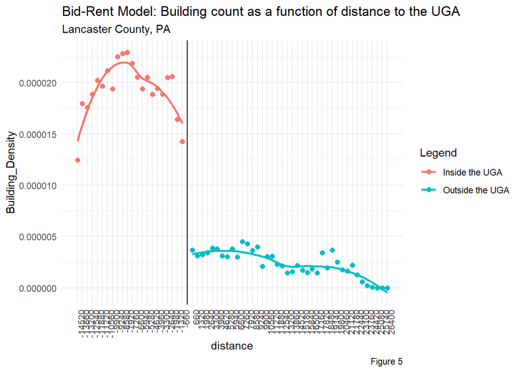

```r
multipleRing <-
  rbind(
    multipleRingBuffer(uga_union, -14520, -660) %>%
    mutate(Legend = "Inside the UGA"),
      multipleRingBuffer(uga_union, 26400, 660) %>%
      mutate(Legend = "Outside the UGA"))

RingsAndTowns <-
  st_intersection(multipleRing, st_make_valid(studyAreaTowns))

buildings.in.RingsAndTowns <-
  aggregate(buildingCentroids,
            RingsAndTowns, sum) %>%
  cbind(RingsAndTowns) %>%
  dplyr::select(-geometry.1) %>%
  mutate(counter = replace_na(counter, 0),
         Area = as.numeric(st_area(.)))

buildings.in.RingsAndTowns_Summarize <-
  buildings.in.RingsAndTowns %>%
  group_by(Legend, distance) %>%
    summarize(Building_Count = sum(counter),
              Area = sum(Area)) %>%
    mutate(Building_Density = Building_Count / Area)

lancaster_building_density <-
  st_drop_geometry(buildings.in.RingsAndTowns_Summarize)

lancaster_bid_rent <-
  ggplot(buildings.in.RingsAndTowns_Summarize, aes(distance,Building_Density, color= Legend))+
  geom_point(size=2)+
  geom_vline(xintercept = 0, linetype = "solid", color = "black") +
  scale_x_continuous(breaks = buildings.in.RingsAndTowns_Summarize$distance, minor_breaks = NULL) +
  geom_smooth(method="loess", se=F)+
  theme_minimal()+
  theme(axis.text.x = element_text(angle = 90, hjust = 1))+
  labs(title = "Bid-Rent Model: Building count as a function of distance to the UGA", subtitle = "Lancaster County, PA", caption = "Figure 5")

print(lancaster_bid_rent)
```

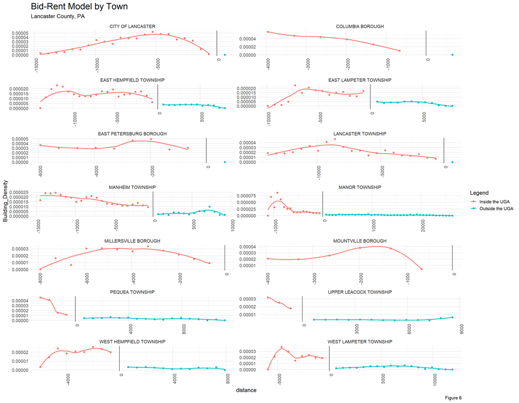

```r
buildings.in.RingsAndTowns_Muni <-
  buildings.in.RingsAndTowns %>%
  group_by(MUNI,Legend, distance) %>%
    summarize(Building_Count = sum(counter),
              Area = sum(Area)) %>%
    mutate(Building_Density = Building_Count / Area)

Muni_building_density <-
  st_drop_geometry(buildings.in.RingsAndTowns_Muni)

Muni_bid_rent <-
  ggplot(buildings.in.RingsAndTowns_Muni, aes(distance,Building_Density, color= Legend))+
  geom_point(size=2)+
  geom_vline(xintercept = 0, linetype = "solid", color = "black") +
  facet_wrap(~MUNI, scales = "free", ncol = 2) +
  geom_smooth(method="loess", se=F)+
  theme_minimal(base_size = 14)+
  labs(title = "Bid-Rent Model by Town", subtitle = "Lancaster County, PA", caption = "Figure 6")+
  theme(axis.text.x = element_text(angle = 90, hjust = 1), plot.title = element_text(size = 22))


print(Muni_bid_rent)
```

# Expansion of Lancaster County’s Urban Growth Area